# EAS648_Lab5_Megroe

Megan Roe

2025-11-30

## Salt Lake City data

Here we will read-in Land Change data and other raster layers that might explain urban development

```r
library(terra)
#first import the land cover/use data
NLCD_2001 <- rast("NLCD_2001_SL.tif")
NLCD_2004 <- rast("NLCD_2004_SL.tif")
NLCD_2006 <- rast("NLCD_2006_SL.tif")
NLCD_2008 <- rast("NLCD_2008_SL.tif")
NLCD_2011 <- rast("NLCD_2011_SL.tif")
NLCD_2013 <- rast("NLCD_2013_SL.tif")
NLCD_2016 <- rast("NLCD_2016_SL.tif")
# Distance to parks and protected areas in km (Euclidian) for the study area
Park_dist <- rast("Parks_dist_SL.tif")
# Road density for a 1 km neighborhood
Rd_dns1km <- rast("Rd_dns1km_SL.tif")
# Distance to water bodies in km (Euclidean)
WaterDist <- rast("WaterDist_SL.tif")
# elevation
DEM <- rast("DEM_SL.tif")
```

Plotting raster data

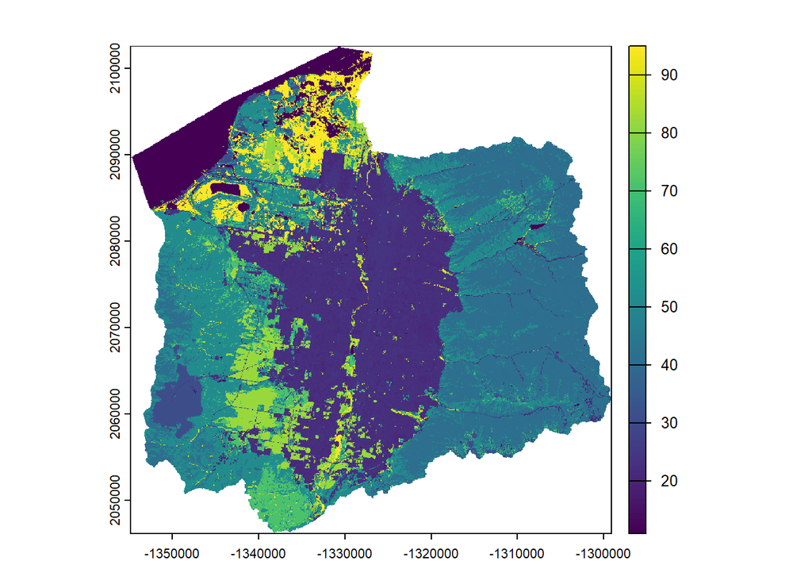

```r
plot(NLCD_2001)
```

## Building a geospatial database using different methods

We need a dataset that describes multiple environmental or landscape layers.

```r
allrasters <- c(NLCD_2001, NLCD_2004, NLCD_2006, NLCD_2008, NLCD_2011, NLCD_2013, NLCD_2016, Park_dist, Rd_dns1km, WaterDist,DEM)
```

We can look at all the rasters in the stack of call individual layer

```r
#call single raster element
allrasters[[1]]
```

```
## class       : SpatRaster
## size        : 1881, 1856, 1  (nrow, ncol, nlyr)
## resolution  : 30, 30  (x, y)
## extent      : -1354815, -1299135, 2046165, 2102595  (xmin, xmax, ymin, ymax)
## coord. ref. : Albers_Conical_Equal_Area
## source      : NLCD_2001_SL.tif
## name        : NLCD_2001_SL
```

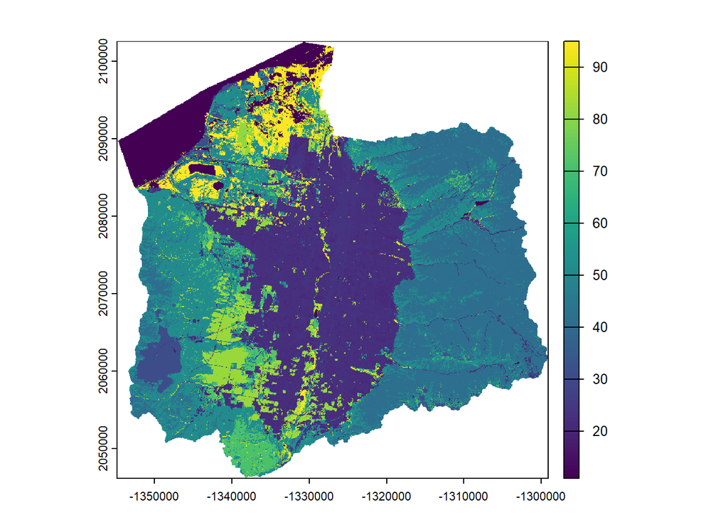

```r
#to run a function on an individual raster e.g., plot
plot(allrasters[[1]])
```

We can convert the stacked raster into a dataframe. This process essentially extracts the values from each raster layer at every cell location on the map. This transforms the stacked rasters into a tabular format suitable for analysis and visualization.

```r
library(tidyverse)
allrastersSL <- as.data.frame(allrasters, xy=TRUE)
## Here we are filtering out the no data values (stored as 128)
allrastersSL <- allrastersSL %>%
  filter (NLCD_2001_SL != 128)
head(allrastersSL)
```

```
##          x       y NLCD_2001_SL NLCD_2004_SL NLCD_2006_SL NLCD_2008_SL
## 1 -1330860 2102550           11           52           52           95
## 2 -1330830 2102550           11           52           52           95
## 3 -1330800 2102550           11           11           11           11
## 4 -1330770 2102550           11           11           11           11
## 5 -1330740 2102550           11           11           11           11
## 6 -1330710 2102550           11           11           71           71
##   NLCD_2011_SL NLCD_2013_SL NLCD_2016_SL Parks_dist_SL Rd_dns1km_SL
## 1           95           95           95      1358.308            0
## 2           95           95           95      1343.317            0
## 3           95           11           11      1328.834            0
## 4           95           11           11      1314.876            0
## 5           95           11           95      1301.461            0
## 6           71           71           71      1288.255            0
##   WaterDist_SL DEM_SL
## 1     301.4963   1281
## 2     305.9412   1281
## 3     313.2092   1281
## 4     323.1099   1281
## 5     330.0000   1281
## 6     331.3608   1281
```

## Sampling

If we want to use random sample, which is often needed in very large datasets, we can do that.

We will use the random sample function to grab a spatial random sample

```r
library(leaflet)
sampleSLrnd <- spatSample(allrasters, size=100, "random", cells=TRUE, xy=TRUE)
head(sampleSLrnd)
```

```
##      cell        x       y NLCD_2001_SL NLCD_2004_SL NLCD_2006_SL NLCD_2008_SL
## 1   71312 -1331310 2101440           11           71           81           71
## 2 1809050 -1315650 2073360           42           42           42           42
## 3 2322834 -1325490 2065050           22           22           22           22
## 4 3436693 -1317720 2047050           NA           NA           NA           NA
## 5 2346790 -1330650 2064660           24           24           24           24
## 6 3100335 -1330380 2052480           23           23           23           23
##   NLCD_2011_SL NLCD_2013_SL NLCD_2016_SL Parks_dist_SL Rd_dns1km_SL
## 1           71           71           71      458.9117   0.00000000
## 2           42           42           42        0.0000   0.03305785
## 3           22           22           22     6940.6411   0.33884299
## 4           NA           NA           NA            NA           NA
## 5           24           24           24    11693.1514   0.30303031
## 6           23           23           23     9210.0000   0.21487603
##   WaterDist_SL DEM_SL
## 1     666.1081   1281
## 2    1182.2437   1879
## 3    1194.3617   1373
## 4           NA     NA
## 5     999.0496   1330
## 6     845.3401   1409
```

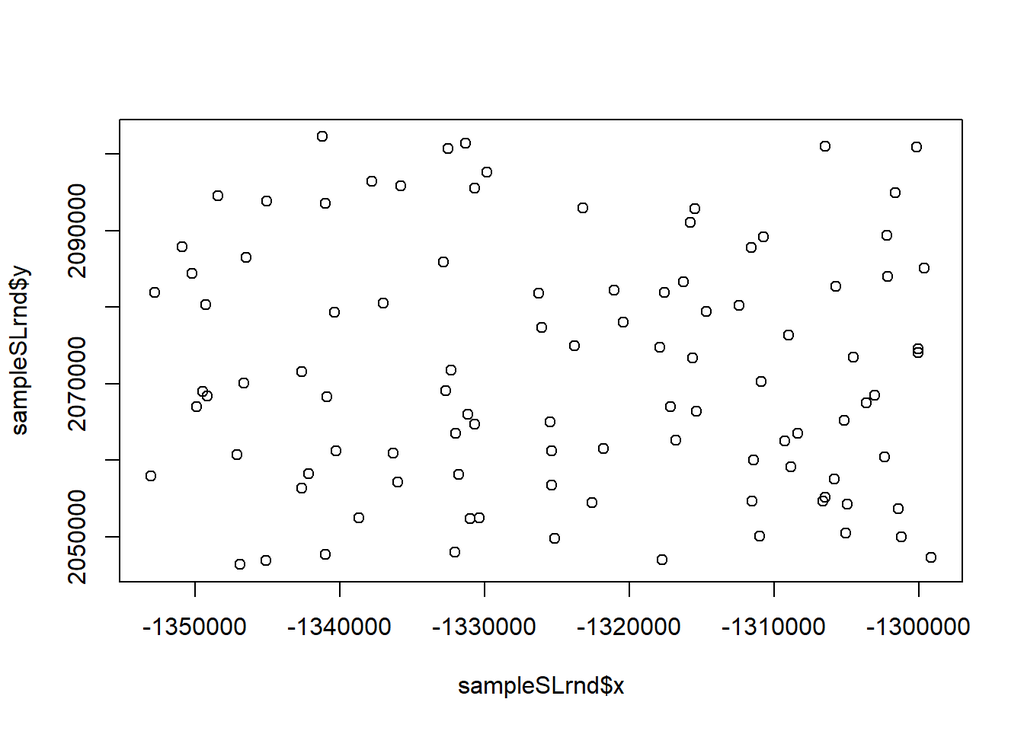

```r
plot(sampleSLrnd$x, sampleSLrnd$y)
```

We can also sample based on a regular grid using

```r
sampleSLreg <- spatSample(allrasters, size=100,  "regular", cells=TRUE, xy=TRUE)
head(sampleSLreg)
```

```
##      cell        x       y NLCD_2001_SL NLCD_2004_SL NLCD_2006_SL NLCD_2008_SL
## 1 3331613 -1352040 2048730           NA           NA           NA           NA
## 2 3331799 -1346460 2048730           NA           NA           NA           NA
## 3 3331985 -1340880 2048730           NA           NA           NA           NA
## 4 3332170 -1335330 2048730           71           71           71           71
## 5 3332356 -1329750 2048730           NA           NA           NA           NA
## 6 3332541 -1324200 2048730           NA           NA           NA           NA
##   NLCD_2011_SL NLCD_2013_SL NLCD_2016_SL Parks_dist_SL Rd_dns1km_SL
## 1           NA           NA           NA            NA           NA
## 2           NA           NA           NA            NA           NA
## 3           NA           NA           NA            NA           NA
## 4           71           71           71      14610.46   0.01469238
## 5           NA           NA           NA            NA           NA
## 6           NA           NA           NA            NA           NA
##   WaterDist_SL DEM_SL
## 1           NA     NA
## 2           NA     NA
## 3           NA     NA
## 4     2495.596   1637
## 5           NA     NA
## 6           NA     NA
```

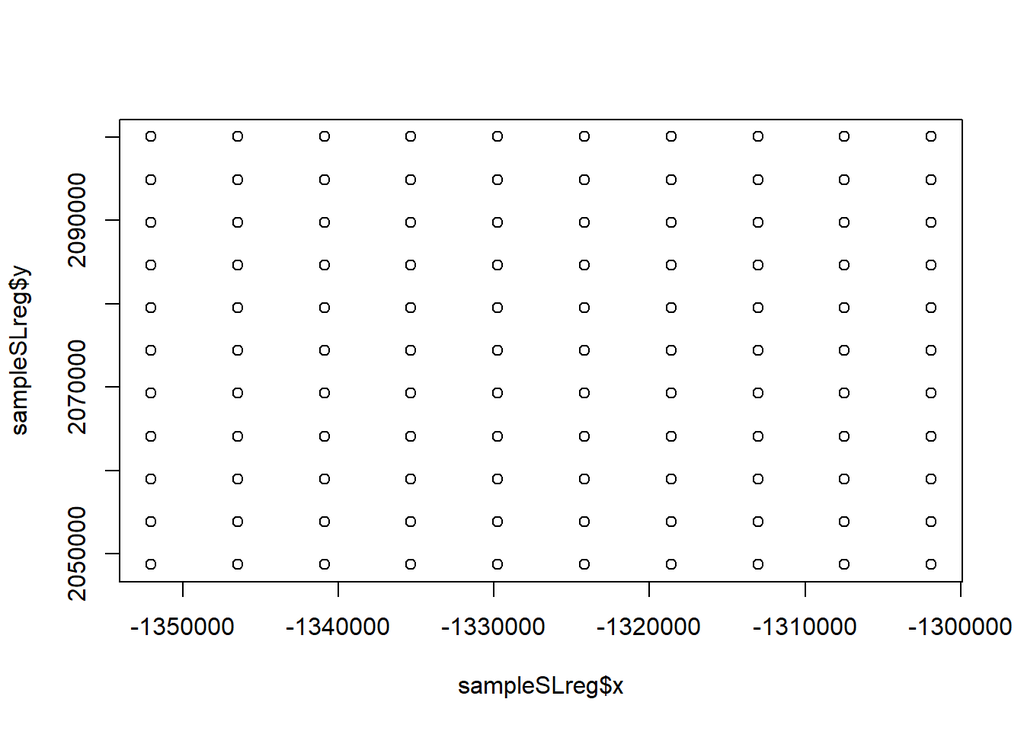

```r
plot(sampleSLreg$x, sampleSLreg$y)
```

### Assessing our dataset

We can use the simple `summary()` and `hist()` functions to evaluate data

```r
summary(sampleSLreg)
```

```
##       cell               x                  y            NLCD_2001_SL
##  Min.   : 157853   Min.   :-1352040   Min.   :2048730   Min.   :11.00
##  1st Qu.: 793951   1st Qu.:-1340880   1st Qu.:2058990   1st Qu.:23.00
##  Median :1745569   Median :-1326975   Median :2074380   Median :41.00
##  Mean   :1745569   Mean   :-1326972   Mean   :2074380   Mean   :43.22
##  3rd Qu.:2697187   3rd Qu.:-1313040   3rd Qu.:2089770   3rd Qu.:52.00
##  Max.   :3333284   Max.   :-1301910   Max.   :2100030   Max.   :90.00
##                                                         NA's   :37
##   NLCD_2004_SL    NLCD_2006_SL    NLCD_2008_SL   NLCD_2011_SL   NLCD_2013_SL
##  Min.   :11.00   Min.   :11.00   Min.   :11.0   Min.   :11.0   Min.   :11.00
##  1st Qu.:23.00   1st Qu.:23.00   1st Qu.:23.0   1st Qu.:23.0   1st Qu.:23.00
##  Median :42.00   Median :41.00   Median :41.0   Median :41.0   Median :41.00
##  Mean   :44.23   Mean   :43.18   Mean   :43.3   Mean   :44.3   Mean   :44.03
##  3rd Qu.:52.00   3rd Qu.:52.00   3rd Qu.:52.0   3rd Qu.:52.0   3rd Qu.:52.00
##  Max.   :95.00   Max.   :95.00   Max.   :95.0   Max.   :95.0   Max.   :95.00
##  NA's   :37      NA's   :37      NA's   :37     NA's   :37     NA's   :37
##   NLCD_2016_SL   Parks_dist_SL    Rd_dns1km_SL      WaterDist_SL
##  Min.   :11.00   Min.   :    0   Min.   :0.00000   Min.   :   0.0
##  1st Qu.:23.00   1st Qu.: 1784   1st Qu.:0.00000   1st Qu.: 666.1
##  Median :41.00   Median : 4699   Median :0.03489   Median :1474.9
##  Mean   :42.89   Mean   : 5630   Mean   :0.09444   Mean   :1535.9
##  3rd Qu.:52.00   3rd Qu.: 8668   3rd Qu.:0.12580   3rd Qu.:2197.4
##  Max.   :95.00   Max.   :17481   Max.   :0.39578   Max.   :4997.1
##  NA's   :37      NA's   :37      NA's   :37        NA's   :37
##      DEM_SL
##  Min.   :1278
##  1st Qu.:1305
##  Median :1509
##  Mean   :1681
##  3rd Qu.:1862
##  Max.   :2878
##  NA's   :37
```

#### Spatial autocorrelation

We can also assess spatial dependency. First we need to transform the data into spatial weights matrix that indicates the geographic relationship between observations. With our matrix, we can assess the specific spatial autocorrelation of our independent variables. We will simply use Moran’s I, which is the most widely use.

```r
# flatten the spatial data to a dataframe that has lat and long
flat_data <- as.data.frame(sampleSLrnd)
# calculate distances between all the points,
dist_matrix <- as.matrix(dist(cbind(flat_data$x, flat_data$y)))
# and generate a matrix of inverse distance weights.
dist_matix.inv <- 1/dist_matrix
diag(dist_matix.inv) <- 0
```

Now we can measure spatial autocorrelation of the variables

```r
library(ape)
Moran.I(sampleSLrnd$Rd_dns1km_SL, dist_matix.inv, na.rm = TRUE)
```

```
## $observed
## [1] 0.1575343
##
## $expected
## [1] -0.01010101
##
## $sd
## [1] 0.02322324
##
## $p.value
## [1] 5.258016e-13
```

### statistical analysis

Now that we have some different samples of the data, let’s do some analysis. We will be looking at the location characteristics of new development in Salt Lake. First we will identify the pixels that have change to urban classes between 2001 and 2016.

```r
allrastersSL <- allrastersSL %>%
    mutate(urbanChg = (NLCD_2001_SL != 21 & NLCD_2001_SL != 22 & NLCD_2001_SL != 23 & NLCD_2001_SL != 24) &  (NLCD_2016_SL == 21 | NLCD_2016_SL == 22  | NLCD_2016_SL == 23 | NLCD_2016_SL == 24))
```

We can map the results

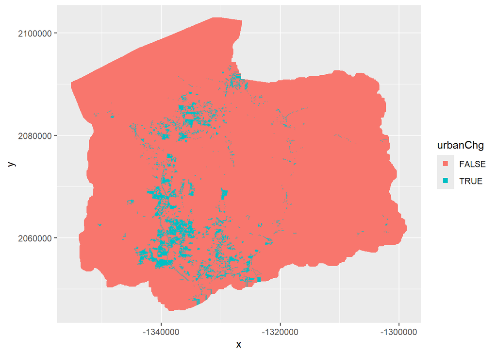

```r
ggplot(allrastersSL, aes(y=y, x=x, color=urbanChg)) +
   geom_point(size=2, shape=15) +
   theme()
```

How much change did Salt Lake experience from 2001 to 2016:

```r
## calculate total new urban impervious for 2016
newUrban <- (sum(as.numeric(allrastersSL$NLCD_2016_SL == 21 | allrastersSL$NLCD_2016_SL == 22 |allrastersSL$NLCD_2016_SL == 23 | allrastersSL$NLCD_2016_SL == 24))) - (sum(as.numeric(allrastersSL$NLCD_2001_SL == 21| allrastersSL$NLCD_2001_SL == 22| allrastersSL$NLCD_2001_SL == 23| allrastersSL$NLCD_2001_SL == 24)))
## calculate total urban impervious for 2001
urban2001 <- (sum(as.numeric(allrastersSL$NLCD_2001_SL == 21| allrastersSL$NLCD_2001_SL == 22| allrastersSL$NLCD_2001_SL == 23| allrastersSL$NLCD_2001_SL == 24)))
## percentage increase in urban impervious
newUrban/urban2001* 100
```

```
## [1] 15.88895
```

We can compare means and plot the variance between newly developed urban areas and the different variables. Let’s look at the influence of the distance to protected areas.

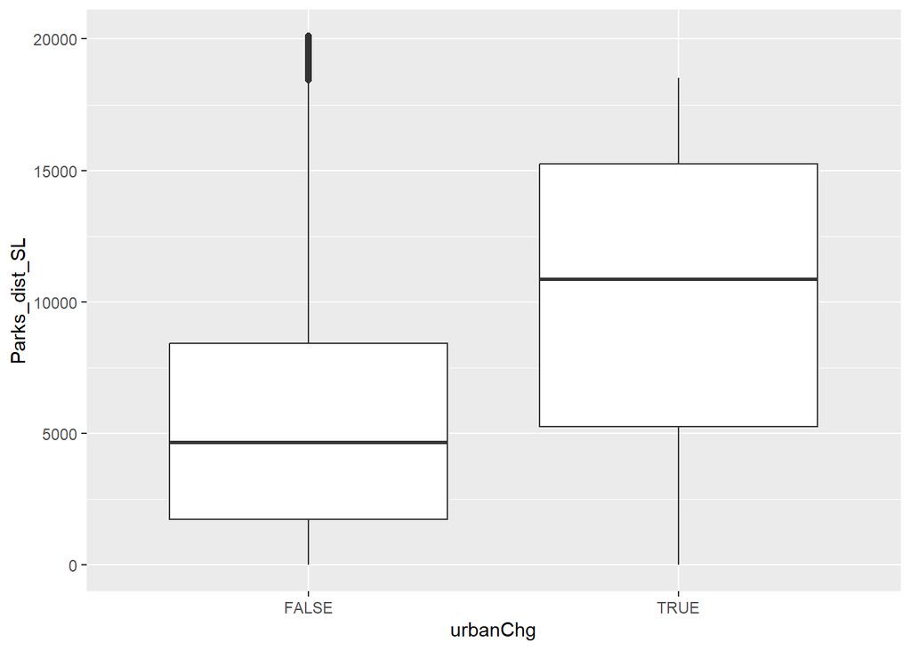

```r
allrastersSL %>%
  filter(NLCD_2001_SL != 21| NLCD_2001_SL != 22| NLCD_2001_SL != 23| NLCD_2001_SL != 24) %>%
ggplot(aes(x=urbanChg, y=Parks_dist_SL)) +
  geom_boxplot()
```

Let’s look at the mean and variance of the variables that might shape where there is new development. We have to reshape the data to achieve this.

```r
library(plyr)
library(reshape2)
```

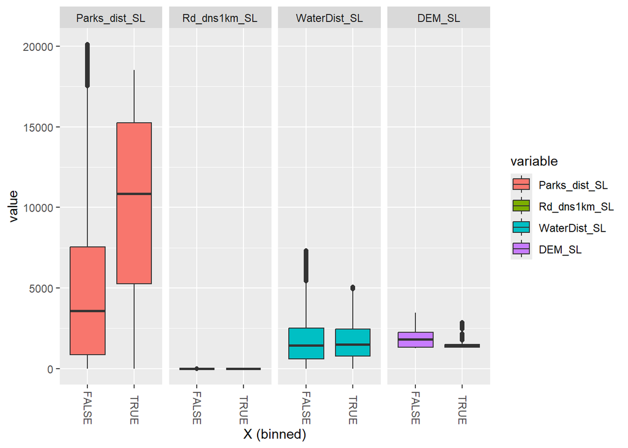

```r
library(plotly)
SL <- allrastersSL %>%
  filter(NLCD_2001_SL != 21 & NLCD_2001_SL != 22 & NLCD_2001_SL != 23 & NLCD_2001_SL != 24)
SL <- SL[10:14]
SLmelt<-melt(SL)
p <- ggplot(SLmelt, aes(x=urbanChg, y=value,fill=variable))+
    geom_boxplot()+
    facet_grid(.~variable)+
    labs(x="X (binned)")+
    theme(axis.text.x=element_text(angle=-90, vjust=0.4,hjust=1))
p
```

### General linear models (Part 1 of Lab)

For our analysis we will take a random sample of our entire dataset (this demonstrate an alternative random sample of a dataframe).

```r
###Grab all the developed cells (presence)
newUrban <- SL %>%
  filter(urbanChg == TRUE)

###Grab all the nondeveloped and not previously urban cells (absence)
nonUrban <- SL %>%
  filter(urbanChg == FALSE)

###Get a random sample of the absence data
### that is twice as large as the presence data
index <- sample(1:nrow(nonUrban), (round(nrow(newUrban)* 2)))
SLsampleUrban <- nonUrban[index, ]

### combine the orginal presence and absence data
SLsample <- cbind(SLsampleUrban, newUrban)

###Consider a train and testing sample by futher subsampling the data
index <- sample(1:nrow(SL), (round(nrow(SL)* 0.01)))
SLsample <- SL[index, ]

###Consider making a training and testing dataset
###This can reduce the computational burden
### It also is a robust goodness of fit method
#SLsample <- SLsample %>% dplyr::mutate(id = row_number())
#Create training set
#train <- SLsample %>% sample_frac(.70)
#Create test set
#test  <- anti_join(SLsample, train, by = 'id')
```

Now that we have a sample, we can fit a model.

```r
fit <- glm(urbanChg ~ Parks_dist_SL + Rd_dns1km_SL + WaterDist_SL + DEM_SL,data=SLsample,family=binomial())
summary(fit)
```

```
##
## Call:
## glm(formula = urbanChg ~ Parks_dist_SL + Rd_dns1km_SL + WaterDist_SL +
##     DEM_SL, family = binomial(), data = SLsample)
##
## Coefficients:
##                 Estimate Std. Error z value Pr(>|z|)
## (Intercept)    2.329e+00  4.698e-01   4.958 7.12e-07 ***
## Parks_dist_SL  1.146e-04  1.009e-05  11.359  < 2e-16 ***
## Rd_dns1km_SL   1.685e+01  5.354e-01  31.481  < 2e-16 ***
## WaterDist_SL   2.106e-04  4.592e-05   4.587 4.49e-06 ***
## DEM_SL        -5.037e-03  3.500e-04 -14.392  < 2e-16 ***
## ---
## Signif. codes:  0 '***' 0.001 '**' 0.01 '*' 0.05 '.' 0.1 ' ' 1
##
## (Dispersion parameter for binomial family taken to be 1)
##
##     Null deviance: 7788.4  on 16616  degrees of freedom
## Residual deviance: 3872.8  on 16612  degrees of freedom
## AIC: 3882.8
##
## Number of Fisher Scoring iterations: 9
```

## **Summary and Interpretation of Model Fit**

We can fit the model without the water distance variable.

```r
fit_withoutwater <- glm(urbanChg ~ Parks_dist_SL + Rd_dns1km_SL + DEM_SL,data=SLsample,family=binomial())
summary(fit_withoutwater)
```

```
##
## Call:
## glm(formula = urbanChg ~ Parks_dist_SL + Rd_dns1km_SL + DEM_SL,
##     family = binomial(), data = SLsample)
##
## Coefficients:
##                 Estimate Std. Error z value Pr(>|z|)
## (Intercept)    1.648e+00  4.315e-01    3.82 0.000133 ***
## Parks_dist_SL  1.286e-04  9.539e-06   13.48  < 2e-16 ***
## Rd_dns1km_SL   1.733e+01  5.263e-01   32.92  < 2e-16 ***
## DEM_SL        -4.477e-03  3.153e-04  -14.20  < 2e-16 ***
## ---
## Signif. codes:  0 '***' 0.001 '**' 0.01 '*' 0.05 '.' 0.1 ' ' 1
##
## (Dispersion parameter for binomial family taken to be 1)
##
##     Null deviance: 7788.4  on 16616  degrees of freedom
## Residual deviance: 3893.7  on 16613  degrees of freedom
## AIC: 3901.7
##
## Number of Fisher Scoring iterations: 9
```

Final model fit:

```r
fit <- glm(urbanChg ~ Parks_dist_SL + Rd_dns1km_SL + DEM_SL + WaterDist_SL,data=SLsample,family=binomial())
summary(fit)
```

```
##
## Call:
## glm(formula = urbanChg ~ Parks_dist_SL + Rd_dns1km_SL + DEM_SL +
##     WaterDist_SL, family = binomial(), data = SLsample)
##
## Coefficients:
##                 Estimate Std. Error z value Pr(>|z|)
## (Intercept)    2.329e+00  4.698e-01   4.958 7.12e-07 ***
## Parks_dist_SL  1.146e-04  1.009e-05  11.359  < 2e-16 ***
## Rd_dns1km_SL   1.685e+01  5.354e-01  31.481  < 2e-16 ***
## DEM_SL        -5.037e-03  3.500e-04 -14.392  < 2e-16 ***
## WaterDist_SL   2.106e-04  4.592e-05   4.587 4.49e-06 ***
## ---
## Signif. codes:  0 '***' 0.001 '**' 0.01 '*' 0.05 '.' 0.1 ' ' 1
##
## (Dispersion parameter for binomial family taken to be 1)
##
##     Null deviance: 7788.4  on 16616  degrees of freedom
## Residual deviance: 3872.8  on 16612  degrees of freedom
## AIC: 3882.8
##
## Number of Fisher Scoring iterations: 9
```

### Goodness of fit

```r
library(ROCR)
```

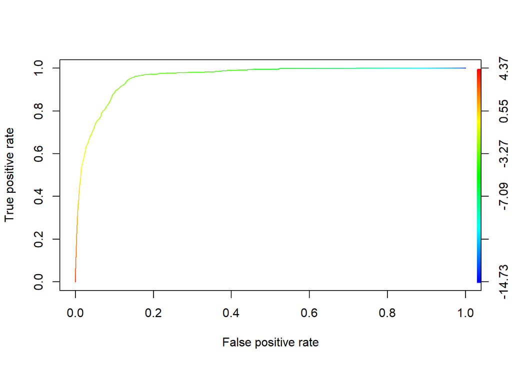

```r
pred <- prediction(predict(fit), SLsample$urbanChg)
perf <- performance(pred,"tpr","fpr")
plot(perf,colorize=TRUE)
```

```r
auc_ROCR <- performance(pred, measure = "auc")
auc_ROCR <- auc_ROCR@y.values[[1]]
auc_ROCR
```

```
## [1] 0.9580273
```

### Predicting likely locations of development

```r
predicted <- predict(allrasters, fit)
```

Now we can visualize this prediction

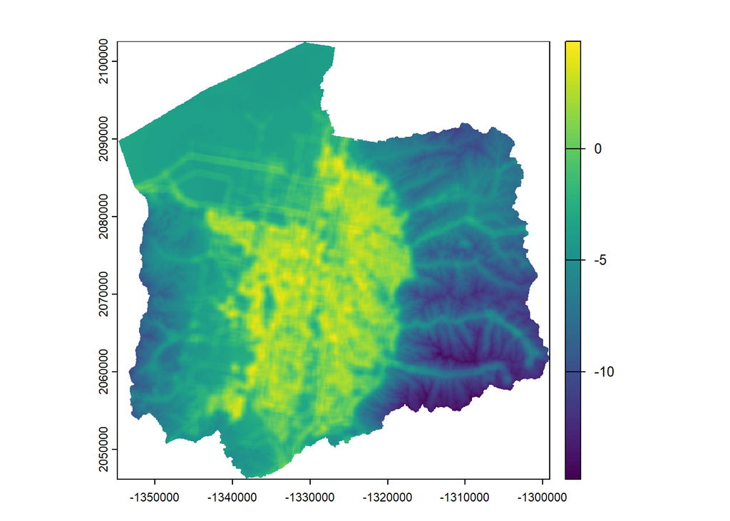

```r
plot(predicted)
```

## Cluster analysis (Part 2 of Lab)

```r
library(fastcluster)
```

```r
library(graphics)
library(ggplot2)
library(ggdendro)
```

This is a dataset of different amenity characteristic for the entire US. Derek developed with dataset using a 10 km by 10 km grid using different sources of data (e.g. NLCD, [SEDAC], social media, cultural monuments).

```
## Simple feature collection with 6 features and 138 fields
## Geometry type: POLYGON
## Dimension:     XY
## Bounding box:  xmin: -1986114 ymin: 3152044 xmax: -1936114 ymax: 3172044
## Projected CRS: NAD83 / Conus Albers
##   GRIDCODE_1 ZooAmusSAL ZooAmusEMP ShopTOT ShopTOTsho HotelTOT HotelSALEV
## 1          1          0          0       0          0        2        431
## 2          2          0          0       0          0        0          0
## 3          3          0          0       0          0        2        538
## 4          4          0          0       0          0        5       1291
## 5          5          0          0       0          0        0          0
## 6          6       1652         15       0          0       15      21049
##   HotelEMPL HosptTOT HosptEMP HighE_TOT HighE_EMP GolfTOT GolfSALEV GolfEMP
## 1         4        0        0         0         0       2      2331      35
## 2         0        0        0         0         0       0         0       0
```

[output cut: 130 more lines]

###Overview of the data

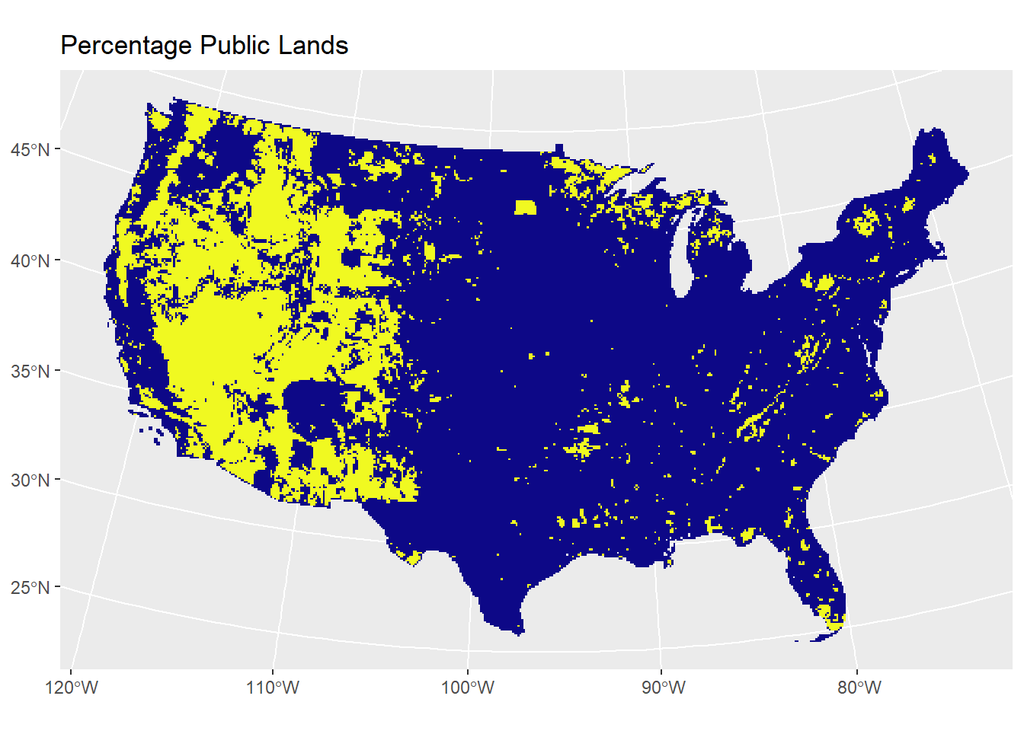

```r
ggplot() +
  geom_sf(data = amenData, mapping = aes(fill = ser00publi), color = NA) +
  scale_fill_viridis_c(option = "plasma", trans = "sqrt") +
  theme(legend.position = "none") +
  ggtitle("Percentage Public Lands")
```

As we will be doing several operation that cannot use spatial data in the sf format, we will need to save the spatial attributes of the data. This will allow us to apply these spatial attribute after our analysis for mapping.

```r
st_geometry(amenData)
```

```
## Geometry set for 79971 features
## Geometry type: POLYGON
## Dimension:     XY
## Bounding box:  xmin: -2356114 ymin: 272043.6 xmax: 2263886 ymax: 3182044
## Projected CRS: NAD83 / Conus Albers
## First 5 geometries:
```

```
## POLYGON ((-1976114 3162044, -1986114 3162044, -...
```

```
## POLYGON ((-1966114 3162044, -1976114 3162044, -...
```

```
## POLYGON ((-1956114 3162044, -1966114 3162044, -...
```

```
## POLYGON ((-1946114 3162044, -1956114 3162044, -...
```

```
## POLYGON ((-1936114 3162044, -1946114 3162044, -...
```

```r
geomData = st_sfc(amenData$geometry)
```

### Tranforming some data to make it meaningful and interpretable

#### Geographic transformations

In geographic relationships, we might assume that the nearer we are to something the more important it is (i.e. there is not a spatial linear relationship with a location attribute). In order to represent this, we can log transform distance variable that we think has this nonlinear relationship.

```r
amenData$HotelEmpDist_log <- log(amenData$HotelDistE + 0.00000001)
amenData$HistMonDist_log <- log(amenData$HistMon_Di + 0.00000001)
amenData$HighEdEmpDist_log <- log(amenData$HigherEdDi + 0.00000001)
amenData$GolfEmpDist_log <- log(amenData$GolfDistEm + 0.00000001)
```

Here we are combining variables to test different hypotheses.

```r
amenData$HousingChg <- amenData$Urb2011 - amenData$Urb2001
```

#### reduce to only the data that we need

In cluster analysis we must provide a data frame or matrix of only the data that will be included in the model. Here, I chose to include the variables that I need to examine percentage of public lands. I chose the varaibles that I thought would have a fairly strong tie to how much public land there is.

```r
amenDataDF<-amenData[,c("HousingChg", "Frst2011",
                        "WaterPct", "ser00publi", "DEM_max","DEM_range",
                        "HikeLength","Wd_wetland", "Emg_wetld",
                        "HotelEmpDist_log","HistMonDist_log",
                        "HighEdEmpDist_log", "GolfEmpDist_log")]
###if you want to add variable look at the names using: names(amenData)
```

We must also omit any `NA`s

```r
## make sure there are no missing data
amenDataDF <- na.omit(amenDataDF)
## we need to make it into a normal dataframe to
## do the analysis
amenDataDF <- as.data.frame(amenDataDF)[1:12]
## calculate z-scores for the dataset
db_scaled <- scale(amenDataDF)
```

### K-means clustering

Typically in kmeans you determine how many clusters to specify beforehand. This can be done by calculating the within groups sum of squares by number of clusters. Basically, we look for a bend in the plot similar to a scree test in factor analysis

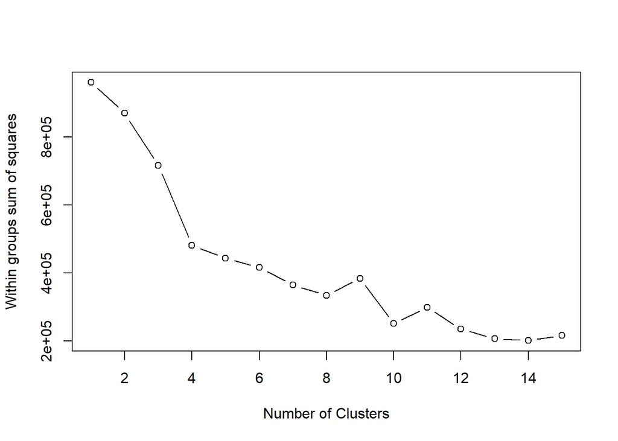

```r
# Determine number of clusters
wss <- (nrow(db_scaled)-1)*sum(apply(db_scaled,2,var))
for (i in 2:15) wss[i] <- sum(kmeans(db_scaled,
   centers=i)$withinss)
plot(1:15, wss, type="b", xlab="Number of Clusters",
  ylab="Within groups sum of squares")
```

```r
# K-Means Cluster Analysis
fit <- kmeans(db_scaled, 5) # 5 cluster solution
```

We can explore the result further by looking at the mean of each variable by the clusters.

```r
# get cluster means
aggregate(db_scaled,by=list(fit$cluster),FUN=mean)
```

```
##   Group.1  HousingChg    Frst2011   WaterPct ser00publi    DEM_max  DEM_range
## 1       1  0.69546532  0.69048600 -0.2384528  1.4336863  1.6820163  2.0360305
## 2       2  0.89163382 -0.64343551 -0.3234747 -0.5643355 -1.0590124 -0.7926785
## 3       3 -0.04959275  0.01277468  0.1051627 -0.4821676 -0.4616644 -0.4375307
## 4       4 -2.57519014 -0.03853823  0.1942472 -0.5314610 -0.6585776 -0.4021539
## 5       5  0.60449340 -0.38473784 -0.1822830  0.8446300  0.7575086  0.2669674
##   HikeLength  Wd_wetland   Emg_wetld HotelEmpDist_log HistMonDist_log
## 1  0.1016138 -0.08889432 -0.21640484        0.2192249       0.2214713
## 2 -0.6059234 -0.08889432 -0.26855707       -4.9382400      -4.9810208
## 3 -0.3404630  0.05894084  0.11000313        0.1591014       0.1646107
## 4 -0.3227896 -0.06379820  0.04415684        0.2518255       0.1557191
## 5  1.2593642 -0.07722724 -0.15887410        0.2133507       0.2446034
##   HighEdEmpDist_log
## 1         0.1190403
## 2        -4.7375877
## 3         0.2010072
## 4         0.2414325
## 5         0.1171736
```

Adding the cluster membership variable back into your original dataset.

```r
# append cluster assignment
amenData <- data.frame(amenData, fit$cluster)
```

In order to plot this data we need to steal the geometry from the original data and apply it to this dataset. We did this earlier.

```r
st_geometry(amenData) <- geomData
```

Now we can plot the kmeans clusters. After visualizing the data, you might want to redo the analysis with other numbers of clusters.

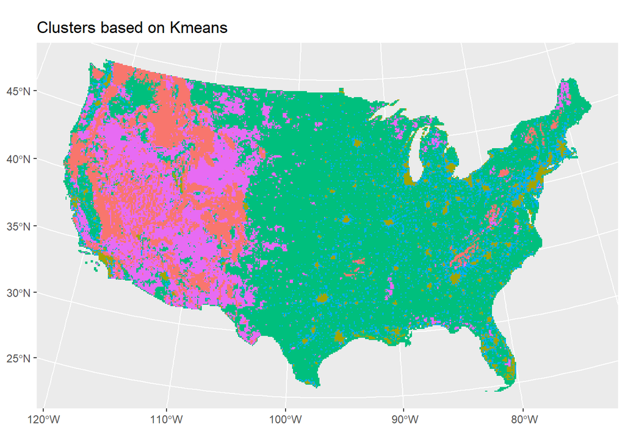

```r
ggplot() +
  geom_sf(data = amenData, mapping = aes(fill = as.factor(fit.cluster)), color = NA) +
  theme(legend.position = "none") +
  ggtitle("Clusters based on Kmeans")
```